# 데이터분석방법론 1 : 제출 과제물 (1주~7주)

### 3-3 The function shapiro.test computes a test of normality based on the degree of linearity of the Q–Q plot. Apply it to the react data. Does it help to remove the outliers?

```r
library( ISwR )
summary(react)
```

```
   Min. 1st Qu.  Median    Mean 3rd Qu.    Max.
-9.0000 -2.0000 -1.0000 -0.7964  0.0000  8.0000
```

```r
help( shapiro.test )
```

| shapiro.test {stats} | R Documentation |
| --- | --- |

Shapiro-Wilk Normality Test

Description

Performs the Shapiro-Wilk test of normality.

Usage

```
shapiro.test(x)
```

Arguments

| `x` | a numeric vector of data values. Missing values are allowed, but the number of non-missing values must be between 3 and 5000. |
| --- | --- |

Value

A list with class `"htest"` containing the following components:

| `statistic` | the value of the Shapiro-Wilk statistic. |
| --- | --- |
| `p.value` | an approximate p-value for the test. This is said in Royston (1995) to be adequate for `p.value < 0.1`. |
| `method` | the character string `"Shapiro-Wilk normality test"`. |
| `data.name` | a character string giving the name(s) of the data. |

Source

The algorithm used is a C translation of the Fortran code described in Royston (1995) and found at http://lib.stat.cmu.edu/apstat/R94. The calculation of the p value is exact for *n = 3*, otherwise approximations are used, separately for *4 ≤ n ≤ 11* and *n ≥ 12*.

References

Patrick Royston (1982) An extension of Shapiro and Wilk's *W* test for normality to large samples. *Applied Statistics*, **31**, 115–124.

Patrick Royston (1982) Algorithm AS 181: The *W* test for Normality. *Applied Statistics*, **31**, 176–180.

Patrick Royston (1995) Remark AS R94: A remark on Algorithm AS 181: The *W* test for normality. *Applied Statistics*, **44**, 547–551.

See Also

`qqnorm` for producing a normal quantile-quantile plot.

Examples

```
shapiro.test(rnorm(100, mean = 5, sd = 3))
shapiro.test(runif(100, min = 2, max = 4))
```

[Package *stats* version 3.2.3 ]

```r
shapiro.test( react )
```

```
	Shapiro-Wilk normality test

data:  react
W = 0.95701, p-value = 2.512e-08
```

- Shapiro-Wilk 정규성 검정에서 p-value가 0.1보다 작으므로 정규분포라고 할 수 없음.

```r
boxplot( react, main="check outlier" )
```

[figure not shown]

```r
react_sort <- sort(react )
react_sort
length( react_sort )
```

1. -9

2. -6

3. -5

4. -5

5. -5

6. -4

7. -4

8. -4

9. -4

10. -4

11. -4

12. -4

13. -4

14. -4

15. -4

16. -4

17. -4

18. -4

19. -4

20. -4

21. -4

22. -4

23. -4

24. -4

25. -4

26. -4

27. -3

28. -3

29. -3

30. -3

31. -3

32. -3

33. -3

34. -3

35. -3

36. -3

37. -3

38. -3

39. -3

40. -3

41. -3

42. -3

43. -3

44. -3

45. -3

46. -3

47. -3

48. -3

49. -3

50. -3

51. -3

52. -3

53. -3

54. -3

55. -3

56. -2

57. -2

58. -2

59. -2

60. -2

61. -2

62. -2

63. -2

64. -2

65. -2

66. -2

67. -2

68. -2

69. -2

70. -2

71. -2

72. -2

73. -2

74. -2

75. -2

76. -2

77. -2

78. -2

79. -2

80. -2

81. -2

82. -2

83. -2

84. -2

85. -2

86. -2

87. -2

88. -2

89. -2

90. -2

91. -2

92. -2

93. -2

94. -2

95. -2

96. -2

97. -2

98. -2

99. -2

100. -2

101. -2

102. -2

103. -2

104. -2

105. -1

106. -1

107. -1

108. -1

109. -1

110. -1

111. -1

112. -1

113. -1

114. -1

115. -1

116. -1

117. -1

118. -1

119. -1

120. -1

121. -1

122. -1

123. -1

124. -1

125. -1

126. -1

127. -1

128. -1

129. -1

130. -1

131. -1

132. -1

133. -1

134. -1

135. -1

136. -1

137. -1

138. -1

139. -1

140. -1

141. -1

142. -1

143. -1

144. -1

145. -1

146. -1

147. -1

148. -1

149. -1

150. -1

151. -1

152. -1

153. -1

154. -1

155. -1

156. -1

157. -1

158. -1

159. -1

160. -1

161. -1

162. -1

163. -1

164. -1

165. -1

166. -1

167. -1

168. -1

169. -1

170. -1

171. -1

172. -1

173. -1

174. -1

175. -1

176. -1

177. -1

178. -1

179. -1

180. -1

181. -1

182. -1

183. -1

184. -1

185. -1

186. -1

187. -1

188. -1

189. -1

190. -1

191. -1

192. -1

193. -1

194. -1

195. -1

196. -1

197. -1

198. -1

199. 0

200. 0

201. 0

202. 0

203. 0

204. 0

205. 0

206. 0

207. 0

208. 0

209. 0

210. 0

211. 0

212. 0

213. 0

214. 0

215. 0

216. 0

217. 0

218. 0

219. 0

220. 0

221. 0

222. 0

223. 0

224. 0

225. 0

226. 0

227. 0

228. 0

229. 0

230. 0

231. 0

232. 0

233. 0

234. 0

235. 0

236. 0

237. 0

238. 0

239. 0

240. 0

241. 0

242. 0

243. 0

244. 0

245. 0

246. 0

247. 0

248. 0

249. 0

250. 0

251. 0

252. 0

253. 0

254. 0

255. 0

256. 0

257. 0

258. 0

259. 0

260. 1

261. 1

262. 1

263. 1

264. 1

265. 1

266. 1

267. 1

268. 1

269. 1

270. 1

271. 1

272. 1

273. 1

274. 1

275. 1

276. 1

277. 1

278. 1

279. 1

280. 1

281. 1

282. 1

283. 1

284. 1

285. 1

286. 1

287. 1

288. 1

289. 1

290. 1

291. 1

292. 1

293. 1

294. 1

295. 1

296. 1

297. 1

298. 1

299. 1

300. 1

301. 2

302. 2

303. 2

304. 2

305. 2

306. 2

307. 2

308. 2

309. 2

310. 2

311. 2

312. 2

313. 2

314. 2

315. 2

316. 2

317. 2

318. 2

319. 2

320. 2

321. 2

322. 2

323. 2

324. 2

325. 2

326. 3

327. 3

328. 3

329. 3

330. 3

331. 4

332. 4

333. 5

334. 8

334

```r
react_no <- react_sort[ 3 : 332 ]
shapiro.test( react_no )
```

```
	Shapiro-Wilk normality test

data:  react_no
W = 0.96567, p-value = 4.996e-07
```

### 3-5 With the rmr data set, plot metabolic rate versus body weight. Fit a linear regression model to the relation. According to the fitted model, what is the predicted metabolic rate for a body weight of 70 kg? Give a 95% confidence interval for the slope of the line.

```r
summary( rmr )
```

```
  body.weight     metabolic.rate
 Min.   : 43.10   Min.   : 870
 1st Qu.: 57.20   1st Qu.:1160
 Median : 64.90   Median :1334
 Mean   : 74.88   Mean   :1340
 3rd Qu.: 88.78   3rd Qu.:1468
 Max.   :143.30   Max.   :2074
```

```r
attach( rmr )
rmr.lm <- lm( metabolic.rate ~ body.weight  )

plot( body.weight,  metabolic.rate,  main="metabolic rate versus body weight"  )
abline( rmr.lm)
detach( rmr )
```

[figure not shown]

```r
summary(rmr.lm)
```

```
Call:
lm(formula = metabolic.rate ~ body.weight)

Residuals:
    Min      1Q  Median      3Q     Max
-245.74 -113.99  -32.05  104.96  484.81

Coefficients:
            Estimate Std. Error t value Pr(>|t|)
(Intercept) 811.2267    76.9755  10.539 2.29e-13 ***
body.weight   7.0595     0.9776   7.221 7.03e-09 ***
---
Signif. codes:  0 '***' 0.001 '**' 0.01 '*' 0.05 '.' 0.1 ' ' 1

Residual standard error: 157.9 on 42 degrees of freedom
Multiple R-squared:  0.5539,	Adjusted R-squared:  0.5433
F-statistic: 52.15 on 1 and 42 DF,  p-value: 7.025e-09
```

```r
pred_v <- 811.2267 +   7.0595 * 70
pred_v
predict(rmr.lm, newdata=data.frame(body.weight=70))
```

1305.3917

**1:** 1305.39362218299

- 몸무게가 70KG 일때 신진대사속도는 약 1305.39로 나옴.

```r
attach( rmr )
new.body_weight <- data.frame( body.weight=40:140 )
pc <- predict(rmr.lm, interval = "confidence", newdata=new.body_weight, level = 0.95 )
pred.weight <- new.body_weight$body.weight

plot( body.weight,  metabolic.rate,  main="metabolic rate versus body weight"  )
abline( rmr.lm)
lines(pred.weight, pc[ ,3], lty = 'dashed', col = 'red')
lines(pred.weight, pc[ ,2], lty = 'dashed', col = 'red')

detach( rmr )
```

[figure not shown]

## 4주

### 4-2. In the lung data, do the three measurement methods give systematically different results? If so, which ones appear to be different?

```r
library(ISwR)
attach(red.cell.folate)
boxplot( folate~ventilation, id.method="y")
```

[figure not shown]

- boxplot을 그려보면, N20+O2,24h 와 N2O+O2.op가 차이가 있다는것을 대략적으로 확인할 수 있음.
- N20+O2,24h 와 N2O+O2.op의 분산도 차이가 있을 수 있다는 것도 알 수 있음.

```r
N20PlushO2_24h <-  red.cell.folate[ ventilation == 'N2O+O2,24h',  ]
N20PlushO2_op <-  red.cell.folate[ ventilation == 'N2O+O2,op',  ]
var.test( N20PlushO2_24h$folate, N20PlushO2_op$folate  )
```

```
	F test to compare two variances

data:  N20PlushO2_24h$folate and N20PlushO2_op$folate
F = 2.5019, num df = 7, denom df = 8, p-value = 0.2223
alternative hypothesis: true ratio of variances is not equal to 1
95 percent confidence interval:
  0.5524726 12.2576914
sample estimates:
ratio of variances
          2.501906
```

```r
redcell.lm <- lm(folate~ventilation)
anova( redcell.lm )
```

|  | Df | Sum Sq | Mean Sq | F value | Pr(>F) |
| --- | --- | --- | --- | --- | --- |
| ventilation | 2 | 15515.77 | 7757.883 | 3.711336 | 0.04358933 |
| Residuals | 19 | 39716.1 | 2090.321 | NA | NA |

- **anova()결과 3그룹간에는 차이가 있다고 할 수 있음.**
- pairwise.t.test()함수로 모든 그룹간의 차이가 있는지 확인함.

```r
pairwise.t.test(folate, ventilation, p.adj="bonferroni")
```

```
	Pairwise comparisons using t tests with pooled SD

data:  folate and ventilation

          N2O+O2,24h N2O+O2,op
N2O+O2,op 0.042      -
O2,24h    0.464      1.000

P value adjustment method: bonferroni
```

- **boxplot()으로도 확인한 것 같이 N2O+O2,24h와 N2O+O2,op 그룹간에 p-value가 0.042이므로, 유효한 차이가가 있다고 할 수 있음.**

## 4-6 Two drugs for the treatment of peptic ulcer were compared (Campbell and Machin, 1993, p. 72). The results were as follows:

[output not shown]

## Compute the test and Fisher’s exact test and discuss the difference. Find an approximate 95% confidence interval for the difference in healing probability.

```r
drug.ulcer <- matrix(  c(23, 7, 18, 12), 2  )

colnames( drug.ulcer ) <- c("Healed","Not Healed")
rownames( drug.ulcer ) <- c("Pirenzepine","Trithiozine")
drug.ulcer
fisher.test( drug.ulcer )
```

|  | Healed | Not Healed |
| --- | --- | --- |
| Pirenzepine | 23 | 18 |
| Trithiozine | 7 | 12 |

```
	Fisher's Exact Test for Count Data

data:  drug.ulcer
p-value = 0.2668
alternative hypothesis: true odds ratio is not equal to 1
95 percent confidence interval:
 0.6301791 7.9380709
sample estimates:
odds ratio
  2.161641
```

- Pirenzepine나 Trithiozine 약물을 처리했을때의 odds ratio가 다르다는 증거가 될 수 없다라고 결과가 나옴.
- 즉, drug.ulcer 데이터에서는 두 약물의 효과가 다르다는 증거가 없어서 같다라고 판단함.
- 95% 신뢰구간은 0.63 ~ 7.93 임.

## 4-7 (From “Mathematics 5” exam, University of Copenhagen, Summer 1969.) From September 20, 1968, to February 1, 1969, an instructor consumed 254 eggs. Every day, he recorded how many eggs broke during boiling so that the white ran out and how many cracked so that the white did not run out. Additionally, he recorded whether the eggs were size A or size B. From February 4, 1969, until April 10, 1969, he consumed 130 eggs, but this time he used a “piercer” to create a small hole in the egg to prevent breaking and cracking. The results were as follows:

| Period | Size | Total | Broken | Cracked |
| --- | --- | --- | --- | --- |
| Sept.20 - Feb.1 | A | 54 | 4 | 8 |
| Sept.20 - Feb.1 | B | 200 | 15 | 28 |
| Feb. 4 - Apr.10 | A | 60 | 4 | 9 |
| Feb. 4 - Apr.10 | B | 70 | 1 | 7 |

## Investigate whether or not the piercer seems to have had an effect.

- Sept.20 - Feb.1 기간동안에는 not piercer 라는 그룹으로, Feb. 4 - Apr.10 기간동안에는 piercer 그룹으로 나눔.
- 삶을때 파손여부에 따라서 success, fail 으로 나누어 아래와 같이 구분함.

[output not shown]

```r
egg.boiling <- matrix(  c(199, 55, 100, 21), 2  )

colnames( egg.boiling ) <- c("success","fail")
rownames( egg.boiling ) <- c("not piercer","piercer")
egg.boiling
chisq.test(egg.boiling)
```

|  | success | fail |
| --- | --- | --- |
| not piercer | 199 | 100 |
| piercer | 55 | 21 |

```
	Pearson's Chi-squared test with Yates' continuity correction

data:  egg.boiling
X-squared = 0.6899, df = 1, p-value = 0.4062
```

- **chisq.test()결과를 보았을때, 달걀에 구멍을 뚫은것은 달걀을 삷을때 파손여부에 영향을 주지 않는것으로 나옴.**

## 5주

### 5-1 The ashina trial was designed to have 80% power if the true treatment difference was 15% and the standard deviation of differences within a person was 20%. Comment on the sample size chosen. (The power calculation was originally done using the approximative formula. The imbalance between the group sizes is due to the use of an open randomization procedure.)

```r
power.t.test(power=.8,delta=.30,sd=.20)
power.t.test(power=.8,delta=.30,sd=.20,alt="one.sided")
```

```
     Two-sample t test power calculation

              n = 8.06031
          delta = 0.3
             sd = 0.2
      sig.level = 0.05
          power = 0.8
    alternative = two.sided

NOTE: n is number in *each* group
```

```
     Two-sample t test power calculation

              n = 6.298691
          delta = 0.3
             sd = 0.2
      sig.level = 0.05
          power = 0.8
    alternative = one.sided

NOTE: n is number in *each* group
```

- 양측검정일때는 샘플수가 9개가 필요하고, 단측검정일때는 7개가 필요함.

```r
( qnorm(.975)+qnorm(.8) )^2 * 2 * (.2/.3)^2
```

6.97678198608808

- Approximate methods을 이용해서 샘플수 계산하면 7개가 필요함.
- 샘플수를 8로 했을때 검정력은 0.8보다 약간 적음.

```r
power.t.test(n=8, delta=.30, sd=.20) # power with eq.size
```

```
     Two-sample t test power calculation

              n = 8
          delta = 0.3
             sd = 0.2
      sig.level = 0.05
          power = 0.7965441
    alternative = two.sided

NOTE: n is number in *each* group
```

```r
d2 <- .30 * sqrt(2/8) / sqrt(1/6+1/10) # corr.f.uneq. size
d2
power.t.test(n=8, delta=d2, sd=.20)
```

0.290473750965556

```
     Two-sample t test power calculation

              n = 8
          delta = 0.2904738
             sd = 0.2
      sig.level = 0.05
          power = 0.7707066
    alternative = two.sided

NOTE: n is number in *each* group
```

- 동일한 수의 샘플을 이용할때 2개의 그룹의 개수가 차이가 있으면 검정력은 떨어짐.

### 5-2 In a trial comparing a binary outcome between two groups, find the required number of patients to find an increase in the success rate from 60% to 75% with a power of 90%. What happens if we reduce the power requirement to 80%?

```r
power.prop.test(power=0.9, p1=0.6, p2=0.75)
power.prop.test(power=0.8, p1=0.6, p2=0.75)
```

```
     Two-sample comparison of proportions power calculation

              n = 202.8095
             p1 = 0.6
             p2 = 0.75
      sig.level = 0.05
          power = 0.9
    alternative = two.sided

NOTE: n is number in *each* group
```

```
     Two-sample comparison of proportions power calculation

              n = 151.8689
             p1 = 0.6
             p2 = 0.75
      sig.level = 0.05
          power = 0.8
    alternative = two.sided

NOTE: n is number in *each* group
```

- 검정력이 90%일때는 203명, 검정력이 80%일때는 152명이 필요하므로, 203 - 152 = 51 명이 줄어듬.

### 5-5 Create a factor in which the blood.glucose variable in the thuesen data is divided into the intervals (4, 7], (7, 9], (9, 12], and (12, 20]. Change the level names to “low”, “intermediate”, “high”, and “very high”.

```r
library( ISwR )
attach(thuesen)
```

```r
summary( blood.glucose )
head( blood.glucose )
f <- cut(blood.glucose, c(4, 7, 9, 12, 20))
levels(f) <- c("low", "intermediate", "high", "very high")
f
```

```
   Min. 1st Qu.  Median    Mean 3rd Qu.    Max.
  4.200   7.075   9.400  10.300  12.700  19.500
```

1. 15.3

2. 10.8

3. 8.1

4. 19.5

5. 7.2

6. 5.3

1. very high

2. high

3. intermediate

4. very high

5. intermediate

6. low

7. high

8. high

9. intermediate

10. very high

11. low

12. low

13. very high

14. very high

15. low

16. intermediate

17. low

18. high

19. very high

20. very high

21. very high

22. low

23. intermediate

24. high

## 6주

### 6-1 The secher data are best analyzed after log-transforming birth weight as well as the abdominal and biparietal diameters. Fit a prediction equation for birth weight. How much is gained by using both diameters in a prediction equation? The sum of the two regression coefficients is almost exactly 3 — can this be given a nice interpretation?

```r
library( ISwR )
```

```r
summary( secher )
head( secher )
```

```
      bwt            bpd               ad              no
 Min.   :1150   Min.   : 64.00   Min.   : 71.0   Min.   :  1.0
 1st Qu.:2400   1st Qu.: 88.00   1st Qu.: 96.0   1st Qu.: 27.5
 Median :2800   Median : 91.00   Median :103.0   Median : 54.0
 Mean   :2739   Mean   : 89.48   Mean   :101.7   Mean   : 54.0
 3rd Qu.:3125   3rd Qu.: 93.00   3rd Qu.:108.0   3rd Qu.: 80.5
 Max.   :4850   Max.   :100.00   Max.   :133.0   Max.   :107.0
```

|  | bwt | bpd | ad | no |
| --- | --- | --- | --- | --- |
| 1 | 2350 | 88 | 92 | 1 |
| 2 | 2450 | 91 | 98 | 2 |
| 3 | 3300 | 94 | 110 | 3 |
| 4 | 1800 | 84 | 89 | 4 |
| 5 | 2900 | 89 | 97 | 5 |
| 6 | 3500 | 100 | 110 | 6 |

- secher 데이터셋은 태아의 출생전의 초음파 측정 데이터와 출생직후의 몸무게 데이터 포함되어짐.

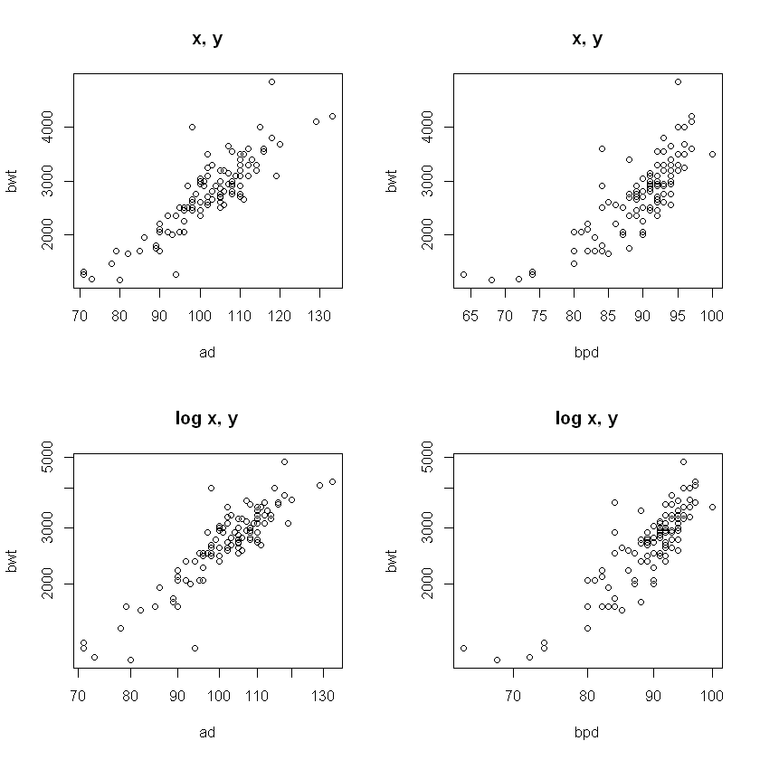

```r
opar <- par(mfrow=c(2,2))
plot(bwt~ad, data=secher, main = "x, y")
plot(bwt~bpd, data=secher, main = "x, y")
plot(bwt~ad, data=secher, log="xy", main = "log x, y")
plot(bwt~bpd, data=secher, log="xy", main = "log x, y")
par(opar)
```

- x, y plot과 log x, y log을 그려보아서 log x, y log이 좀더 적합하게 보여짐.

```r
secher.lm1 <- lm( log(bwt) ~ log(ad) + log(bpd), data=secher )
summary( secher.lm1 )
secher.lm2 <- lm( log(bwt) ~ log(ad) , data=secher )
summary( secher.lm2 )
secher.lm3 <- lm( log(bwt) ~ log(bpd) , data=secher )
summary( secher.lm3 )
```

```
Call:
lm(formula = log(bwt) ~ log(ad) + log(bpd), data = secher)

Residuals:
     Min       1Q   Median       3Q      Max
-0.35074 -0.06741 -0.00792  0.05750  0.36360

Coefficients:
            Estimate Std. Error t value Pr(>|t|)
(Intercept)  -5.8615     0.6617  -8.859 2.36e-14 ***
log(ad)       1.4667     0.1467   9.998  < 2e-16 ***
log(bpd)      1.5519     0.2294   6.764 8.09e-10 ***
---
Signif. codes:  0 '***' 0.001 '**' 0.01 '*' 0.05 '.' 0.1 ' ' 1

Residual standard error: 0.1068 on 104 degrees of freedom
Multiple R-squared:  0.8583,	Adjusted R-squared:  0.8556
F-statistic: 314.9 on 2 and 104 DF,  p-value: < 2.2e-16
```

```
Call:
lm(formula = log(bwt) ~ log(ad), data = secher)

Residuals:
     Min       1Q   Median       3Q      Max
-0.58560 -0.06609  0.00184  0.07479  0.48435

Coefficients:
            Estimate Std. Error t value Pr(>|t|)
(Intercept)  -2.4446     0.5103  -4.791 5.49e-06 ***
log(ad)       2.2365     0.1105  20.238  < 2e-16 ***
---
Signif. codes:  0 '***' 0.001 '**' 0.01 '*' 0.05 '.' 0.1 ' ' 1

Residual standard error: 0.1275 on 105 degrees of freedom
Multiple R-squared:  0.7959,	Adjusted R-squared:  0.794
F-statistic: 409.6 on 1 and 105 DF,  p-value: < 2.2e-16
```

```
Call:
lm(formula = log(bwt) ~ log(bpd), data = secher)

Residuals:
     Min       1Q   Median       3Q      Max
-0.36478 -0.09725  0.01251  0.07703  0.51154

Coefficients:
            Estimate Std. Error t value Pr(>|t|)
(Intercept)  -7.0862     0.9062  -7.819 4.35e-12 ***
log(bpd)      3.3320     0.2017  16.516  < 2e-16 ***
---
Signif. codes:  0 '***' 0.001 '**' 0.01 '*' 0.05 '.' 0.1 ' ' 1

Residual standard error: 0.1488 on 105 degrees of freedom
Multiple R-squared:  0.7221,	Adjusted R-squared:  0.7194
F-statistic: 272.8 on 1 and 105 DF,  p-value: < 2.2e-16
```

### 6-7 Perform a two-way analysis of variance on the tb.dilute data. Modify the model to have a dose effect that is linear in log dose. Compute a confidence interval for the slope. An alternative approach could be to calculate a slope for each animal and perform a test based on them. Compute a confidence interval for the mean slope, and compare it with the preceding result.

```r
summary( tb.dilute )
head( tb.dilute )
```

```
    reaction     animal logdose
 Min.   : 8.50   1:3    0.5 :6
 1st Qu.:11.31   2:3    0   :6
 Median :13.12   3:3    -0.5:6
 Mean   :13.17   4:3
 3rd Qu.:15.44   5:3
 Max.   :17.50   6:3
```

|  | reaction | animal | logdose |
| --- | --- | --- | --- |
| 1 | 13.25 | 1 | 0.5 |
| 2 | 11.25 | 1 | 0 |
| 3 | 8.5 | 1 | -0.5 |
| 4 | 14.25 | 2 | 0.5 |
| 5 | 11.75 | 2 | 0 |
| 6 | 10 | 2 | -0.5 |

- tb.dilute 데이터는 tuberculin을 희석시킨 것에 대한 약물 검사 데이터임.
- reaction은 연속형 데이터, animal과 logdose는 범주형 데이터임.

```r
tb.dilute.anova <- anova( lm(reaction ~ animal + logdose, data=tb.dilute) )
tb.dilute.anova
```

|  | Df | Sum Sq | Mean Sq | F value | Pr(>F) |
| --- | --- | --- | --- | --- | --- |
| animal | 5 | 35.20833 | 7.041667 | 8.264059 | 0.002527056 |
| logdose | 2 | 72.39583 | 36.19792 | 42.48166 | 1.294853e-05 |
| Residuals | 10 | 8.520833 | 0.8520833 | NA | NA |

```r
attach(tb.dilute)
```

```r
logdose
class(logdose)
tb.dilute$linerdose <- rep( c(0.5, 0, -0.5), 6 )
class(linerdose)
linerdose
```

1. 0.5

2. 0

3. -0.5

4. 0.5

5. 0

6. -0.5

7. 0.5

8. 0

9. -0.5

10. 0.5

11. 0

12. -0.5

13. 0.5

14. 0

15. -0.5

16. 0.5

17. 0

18. -0.5

"factor"

"numeric"

1. 0.5

2. 0

3. -0.5

4. 0.5

5. 0

6. -0.5

7. 0.5

8. 0

9. -0.5

10. 0.5

11. 0

12. -0.5

13. 0.5

14. 0

15. -0.5

16. 0.5

17. 0

18. -0.5

- logdose는 범주형이기 때문에 선형효과를 알아보기 위해서는 연속형 변수로 변환이 필요함.

```r
tb.dilute.lm <- lm(reaction ~ animal + linerdose, data=tb.dilute)
tb.dilute.lm
summary( tb.dilute.lm )
```

```
Call:
lm(formula = reaction ~ animal + linerdose, data = tb.dilute)

Coefficients:
(Intercept)      animal2      animal3      animal4      animal5      animal6
     11.000        1.000        2.167        2.167        3.583        4.083
  linerdose
      4.792
```

```
Call:
lm(formula = reaction ~ animal + linerdose, data = tb.dilute)

Residuals:
     Min       1Q   Median       3Q      Max
-1.72917 -0.22917 -0.08333  0.23437  2.41667

Coefficients:
            Estimate Std. Error t value Pr(>|t|)
(Intercept)  11.0000     0.6039  18.214 1.45e-09 ***
animal2       1.0000     0.8541   1.171 0.266408
animal3       2.1667     0.8541   2.537 0.027637 *
animal4       2.1667     0.8541   2.537 0.027637 *
animal5       3.5833     0.8541   4.195 0.001497 **
animal6       4.0833     0.8541   4.781 0.000571 ***
linerdose     4.7917     0.6039   7.934 7.07e-06 ***
---
Signif. codes:  0 '***' 0.001 '**' 0.01 '*' 0.05 '.' 0.1 ' ' 1

Residual standard error: 1.046 on 11 degrees of freedom
Multiple R-squared:  0.8963,	Adjusted R-squared:  0.8398
F-statistic: 15.85 on 6 and 11 DF,  p-value: 7.816e-05
```

```r
4.7917 + 0.6039 * qt( c(0.025, 0.975), 11)
```

1. 3.46252506182066

2. 6.12087493817934

- linerdose의 효과의 95% 신뢰구간은 3.46 ~ 6.12 임.

```r
slopes <- reaction[logdose==0.5] - reaction[logdose==-0.5]
slopes
t.test(slopes)
```

1. 4.75

2. 4.25

3. 5.25

4. 5

5. 3.75

6. 5.75

```
	One Sample t-test

data:  slopes
t = 16.4286, df = 5, p-value = 1.525e-05
alternative hypothesis: true mean is not equal to 0
95 percent confidence interval:
 4.041914 5.541420
sample estimates:
mean of x
 4.791667
```

- 평균 기울기값은 4.7이고, 신뢰구간은 4.04 ~ 5.5 임.

```r
anova(lm(reaction ~ animal*ld))
```

|  | Df | Sum Sq | Mean Sq | F value | Pr(>F) |
| --- | --- | --- | --- | --- | --- |
| animal | 5 | 35.20833 | 7.041667 | 3.926428 | 0.06308046 |
| ld | 1 | 68.88021 | 68.88021 | 38.40755 | 0.0008133352 |
| animal:ld | 5 | 1.276042 | 0.2552083 | 0.142304 | 0.9753664 |
| Residuals | 6 | 10.76042 | 1.793403 | NA | NA |

### 6-13 For the juul data, fit a model for igf1 with interactions between age, sex, and Tanner stage for those under 25 years old. Explain the interpretation of this model. Hint: A plot of the fitted values against age should be helpful. Use diagnostic plots to evaluate possible transformations of the dependent variable: untransformed, log, or square root.

```r
summary(juul)
```

```
      age            menarche          sex             igf1
 Min.   : 0.170   Min.   :1.000   Min.   :1.000   Min.   : 25.0
 1st Qu.: 9.053   1st Qu.:1.000   1st Qu.:1.000   1st Qu.:202.2
 Median :12.560   Median :1.000   Median :2.000   Median :313.5
 Mean   :15.095   Mean   :1.476   Mean   :1.534   Mean   :340.2
 3rd Qu.:16.855   3rd Qu.:2.000   3rd Qu.:2.000   3rd Qu.:462.8
 Max.   :83.000   Max.   :2.000   Max.   :2.000   Max.   :915.0
 NA's   :5        NA's   :635     NA's   :5       NA's   :321
     tanner        testvol
 Min.   :1.00   Min.   : 1.000
 1st Qu.:1.00   1st Qu.: 1.000
 Median :2.00   Median : 3.000
 Mean   :2.64   Mean   : 7.896
 3rd Qu.:5.00   3rd Qu.:15.000
 Max.   :5.00   Max.   :30.000
 NA's   :240    NA's   :859
```

```r
juul.under25 <- juul[ age < 25, ]
summary( juul.under25 )
```

```
      age           menarche          sex             igf1
 Min.   : 0.17   Min.   :1.000   Min.   :1.000   Min.   : 25.0
 1st Qu.: 9.01   1st Qu.:1.000   1st Qu.:1.000   1st Qu.:203.0
 Median :12.54   Median :1.000   Median :2.000   Median :314.5
 Mean   :15.09   Mean   :1.472   Mean   :1.533   Mean   :341.1
 3rd Qu.:16.79   3rd Qu.:2.000   3rd Qu.:2.000   3rd Qu.:464.0
 Max.   :83.00   Max.   :2.000   Max.   :2.000   Max.   :915.0
 NA's   :10      NA's   :640     NA's   :10      NA's   :331
     tanner         testvol
 Min.   :1.000   Min.   : 1.000
 1st Qu.:1.000   1st Qu.: 1.000
 Median :2.000   Median : 3.000
 Mean   :2.629   Mean   : 7.896
 3rd Qu.:5.000   3rd Qu.:15.000
 Max.   :5.000   Max.   :30.000
 NA's   :245     NA's   :859
```

```r
detach ( juul )
```

attach( juul.under25 )

```r
summary( lm( igf1 ~ age + sex + tanner  ) )
```

```
Call:
lm(formula = igf1 ~ age + sex + tanner)

Residuals:
    Min      1Q  Median      3Q     Max
-291.37  -80.52  -12.95   63.86  512.37

Coefficients:
            Estimate Std. Error t value Pr(>|t|)
(Intercept)  174.340     15.846  11.002  < 2e-16 ***
age           -4.923      1.058  -4.654 3.83e-06 ***
sex           14.797      9.082   1.629    0.104
tanner        76.451      3.547  21.553  < 2e-16 ***
---
Signif. codes:  0 '***' 0.001 '**' 0.01 '*' 0.05 '.' 0.1 ' ' 1

Residual standard error: 124.8 on 783 degrees of freedom
  (552 observations deleted due to missingness)
Multiple R-squared:  0.4841,	Adjusted R-squared:  0.4821
F-statistic: 244.9 on 3 and 783 DF,  p-value: < 2.2e-16
```

- 상호작용효과 없이 age, sex, tanner변수에 대해서 igf1 을 적합했을때, sex는 효과가 없는것으로 보여짐.

```r
summary( lm( igf1 ~ age * sex * tanner  ) )
```

```
Call:
lm(formula = igf1 ~ age * sex * tanner)

Residuals:
    Min      1Q  Median      3Q     Max
-274.72  -69.50   -8.93   51.55  428.33

Coefficients:
                Estimate Std. Error t value Pr(>|t|)
(Intercept)    -233.5142    70.9667  -3.290 0.001045 **
age              29.4979     6.9468   4.246 2.44e-05 ***
sex              63.9432    54.0420   1.183 0.237086
tanner          298.4854    36.7958   8.112 1.93e-15 ***
age:sex          -0.3227     5.5481  -0.058 0.953639
age:tanner      -15.1049     2.3411  -6.452 1.94e-10 ***
sex:tanner      -69.5113    20.4228  -3.404 0.000699 ***
age:sex:tanner    3.4927     1.4624   2.388 0.017162 *
---
Signif. codes:  0 '***' 0.001 '**' 0.01 '*' 0.05 '.' 0.1 ' ' 1

Residual standard error: 106.1 on 779 degrees of freedom
  (552 observations deleted due to missingness)
Multiple R-squared:  0.6287,	Adjusted R-squared:  0.6254
F-statistic: 188.4 on 7 and 779 DF,  p-value: < 2.2e-16
```

- 각각의 상호작용 효과를 확인하면, age:tanner , sex:tanner 가 아주 유의하다고 보여지고, age:sex:tanner 는 유의하지만 age:tanner 의 효과에 의한 결과로 보여져서 유의하지는 않는것으로 보여짐.

## 7주

### 7-1 In the malaria data set, analyze the risk of malaria with age and log-transformed antibody level as explanatory variables.

```r
summary( malaria )
head( malaria )
```

```
    subject            age              ab              mal
 Min.   :  1.00   Min.   : 3.00   Min.   :   2.0   Min.   :0.00
 1st Qu.: 25.75   1st Qu.: 5.75   1st Qu.:  29.0   1st Qu.:0.00
 Median : 50.50   Median : 9.00   Median : 111.0   Median :0.00
 Mean   : 50.50   Mean   : 8.86   Mean   : 311.5   Mean   :0.27
 3rd Qu.: 75.25   3rd Qu.:12.00   3rd Qu.: 373.8   3rd Qu.:1.00
 Max.   :100.00   Max.   :15.00   Max.   :2066.0   Max.   :1.00
```

|  | subject | age | ab | mal |
| --- | --- | --- | --- | --- |
| 1 | 1 | 15 | 546 | 0 |
| 2 | 2 | 14 | 268 | 0 |
| 3 | 3 | 12 | 284 | 0 |
| 4 | 4 | 15 | 38 | 0 |
| 5 | 5 | 14 | 827 | 0 |
| 6 | 6 | 12 | 252 | 0 |

- subject : subject code.
- age : age in years.
- ab : antibody level.
- mal : a numeric vector code, Malaria: 0: no, 1: yes.

```r
malaria.glm <- glm( mal ~ age + log(ab ) , family = binomial,  data=malaria)
summary( malaria.glm )
```

```
Call:
glm(formula = mal ~ age + log(ab), family = binomial, data = malaria)

Deviance Residuals:
    Min       1Q   Median       3Q      Max
-1.8492  -0.7536  -0.4838   0.8809   2.5796

Coefficients:
            Estimate Std. Error z value Pr(>|z|)
(Intercept)  2.57234    0.95184   2.702 0.006883 **
age         -0.06546    0.06772  -0.967 0.333703
log(ab)     -0.68235    0.19552  -3.490 0.000483 ***
---
Signif. codes:  0 '***' 0.001 '**' 0.01 '*' 0.05 '.' 0.1 ' ' 1

(Dispersion parameter for binomial family taken to be 1)

    Null deviance: 116.652  on 99  degrees of freedom
Residual deviance:  98.017  on 97  degrees of freedom
AIC: 104.02

Number of Fisher Scoring iterations: 5
```

```r
exp( -0.68 )
```

0.50661699236559

```r
summary(  graft.vs.host  )
head(  graft.vs.host  )
```

```
      pnr         rcpage          donage           type            preg
 Min.   : 1   Min.   :13.00   Min.   :14.00   Min.   :1.000   Min.   :0.0000
 1st Qu.:10   1st Qu.:20.00   1st Qu.:20.00   1st Qu.:1.000   1st Qu.:0.0000
 Median :19   Median :23.00   Median :23.00   Median :2.000   Median :0.0000
 Mean   :19   Mean   :25.43   Mean   :25.81   Mean   :1.973   Mean   :0.2703
 3rd Qu.:28   3rd Qu.:29.00   3rd Qu.:34.00   3rd Qu.:3.000   3rd Qu.:1.0000
 Max.   :37   Max.   :43.00   Max.   :43.00   Max.   :3.000   Max.   :1.0000
     index             gvhd             time             dead
 Min.   : 0.270   Min.   :0.0000   Min.   :  41.0   Min.   :0.0000
 1st Qu.: 0.920   1st Qu.:0.0000   1st Qu.: 177.0   1st Qu.:0.0000
 Median : 2.010   Median :0.0000   Median : 667.0   Median :0.0000
 Mean   : 2.556   Mean   :0.4595   Mean   : 669.8   Mean   :0.4865
 3rd Qu.: 3.730   3rd Qu.:1.0000   3rd Qu.:1105.0   3rd Qu.:1.0000
 Max.   :10.110   Max.   :1.0000   Max.   :1504.0   Max.   :1.0000
```

|  | pnr | rcpage | donage | type | preg | index | gvhd | time | dead |
| --- | --- | --- | --- | --- | --- | --- | --- | --- | --- |
| 1 | 1 | 27 | 23 | 2 | 0 | 0.27 | 0 | 95 | 1 |
| 2 | 2 | 13 | 18 | 2 | 0 | 0.31 | 0 | 1385 | 0 |
| 3 | 3 | 19 | 19 | 1 | 0 | 0.39 | 0 | 465 | 1 |
| 4 | 4 | 21 | 22 | 2 | 0 | 0.48 | 0 | 810 | 1 |
| 5 | 5 | 28 | 38 | 2 | 0 | 0.49 | 0 | 1497 | 0 |
| 6 | 6 | 22 | 20 | 2 | 0 | 0.5 | 0 | 1181 | 1 |

- pnr a numeric vector patient number.
- rcpage a numeric vector, age of recipient (years).
- donage a numeric vector, age of donor (years).
- type a numeric vector, type of leukaemia coded 1: AML, 2: ALL, 3: CML for acute myeloid, acute lymphatic, and chronic myeloid leukaemia.
- preg a numeric vector code indicating whether donor has been pregnant. 0: no, 1: yes.
- index a numeric vector giving an index of mixed epidermal celllymphocyte reactions.
- gvhd a numeric vector code, graft-versus-host disease, 0: no, 1: yes.
- time a numeric vector, follow-up time
- dead a numeric vector code, 0: no (censored), 1: yes
- type , preg , gvhd 는 범주형변수이지만, numberic형으로 되어있어서 범주형으로 변환이 필요함.

```r
ix <- c("preg", "gvhd")
graft.vs.host[ix] <- lapply(graft.vs.host[ix], factor, levels=0:1, labels=c("No","Yes"))
```

```r
graft.vs.host$type <- factor(graft.vs.host$type, labels=c("AML", "ALL", "CML"))
summary( graft.vs.host )
```

```
      pnr         rcpage          donage       type     preg
 Min.   : 1   Min.   :13.00   Min.   :14.00   AML:11   No :27
 1st Qu.:10   1st Qu.:20.00   1st Qu.:20.00   ALL:16   Yes:10
 Median :19   Median :23.00   Median :23.00   CML:10
 Mean   :19   Mean   :25.43   Mean   :25.81
 3rd Qu.:28   3rd Qu.:29.00   3rd Qu.:34.00
 Max.   :37   Max.   :43.00   Max.   :43.00
     index         gvhd         time             dead
 Min.   : 0.270   No :20   Min.   :  41.0   Min.   :0.0000
 1st Qu.: 0.920   Yes:17   1st Qu.: 177.0   1st Qu.:0.0000
 Median : 2.010            Median : 667.0   Median :0.0000
 Mean   : 2.556            Mean   : 669.8   Mean   :0.4865
 3rd Qu.: 3.730            3rd Qu.:1105.0   3rd Qu.:1.0000
 Max.   :10.110            Max.   :1504.0   Max.   :1.0000
```

```r
summary(glm(dead ~ rcpage + donage + index + time  , family=binomial, data=graft.vs.host))
```

```
Call:
glm(formula = dead ~ rcpage + donage + index + time, family = binomial,
    data = graft.vs.host)

Deviance Residuals:
    Min       1Q   Median       3Q      Max
-1.3826  -0.4734  -0.1096   0.3712   2.4798

Coefficients:
             Estimate Std. Error z value Pr(>|z|)
(Intercept)  2.411908   2.431663   0.992  0.32126
rcpage       0.027348   0.093341   0.293  0.76953
donage       0.024059   0.093789   0.257  0.79755
index       -0.095181   0.252688  -0.377  0.70642
time        -0.005482   0.001694  -3.236  0.00121 **
---
Signif. codes:  0 '***' 0.001 '**' 0.01 '*' 0.05 '.' 0.1 ' ' 1

(Dispersion parameter for binomial family taken to be 1)

    Null deviance: 51.266  on 36  degrees of freedom
Residual deviance: 24.701  on 32  degrees of freedom
AIC: 34.701

Number of Fisher Scoring iterations: 6
```

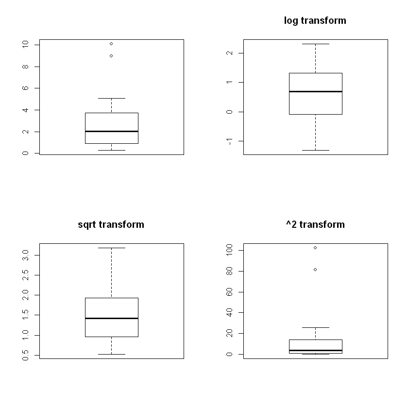

```r
opar <- par(mfrow=c(2,2))
boxplot( graft.vs.host$index )
boxplot( log( graft.vs.host$index ), main="log transform" )
boxplot( sqrt( graft.vs.host$index ), main="sqrt transform" )
boxplot( ( graft.vs.host$index )^2 , main="^2 transform" )
par( opar )
```

- 여러가지 변환을 해서 log변환시에 정규분포에 가장 가까움.

```r
summary(glm(dead ~ rcpage + donage + log(index) + time  , family=binomial, data=graft.vs.host))
```

```
Call:
glm(formula = dead ~ rcpage + donage + log(index) + time, family = binomial,
    data = graft.vs.host)

Deviance Residuals:
     Min        1Q    Median        3Q       Max
-1.42295  -0.45551  -0.06832   0.29150   2.19549

Coefficients:
             Estimate Std. Error z value Pr(>|z|)
(Intercept)  2.383625   2.429597   0.981  0.32655
rcpage       0.062195   0.103487   0.601  0.54785
donage       0.014828   0.102491   0.145  0.88497
log(index)  -0.946208   0.737814  -1.282  0.19969
time        -0.005944   0.001880  -3.163  0.00156 **
---
Signif. codes:  0 '***' 0.001 '**' 0.01 '*' 0.05 '.' 0.1 ' ' 1

(Dispersion parameter for binomial family taken to be 1)

    Null deviance: 51.266  on 36  degrees of freedom
Residual deviance: 22.978  on 32  degrees of freedom
AIC: 32.978

Number of Fisher Scoring iterations: 6
```

- index에 대해서 로그변환 이전과 이후 모두 유의하지 않는것으로 나옴.
- rcpage, donage 변수도 유의하지 않는것으로 나와서 변수를 제거하고 time과 범주형 변수인 type, preg, gvhd에 대해서 모형 적합을 시도함.

```r
summary(glm(dead ~ type + time, family=binomial, data=graft.vs.host))
```

```
Call:
glm(formula = dead ~ type + time, family = binomial, data = graft.vs.host)

Deviance Residuals:
    Min       1Q   Median       3Q      Max
-1.5091  -0.2355  -0.1019   0.3158   2.2856

Coefficients:
             Estimate Std. Error z value Pr(>|z|)
(Intercept)  4.026403   1.424463   2.827  0.00470 **
typeALL      0.122518   1.283641   0.095  0.92396
typeCML     -2.119214   1.505347  -1.408  0.15919
time        -0.005660   0.001872  -3.024  0.00249 **
---
Signif. codes:  0 '***' 0.001 '**' 0.01 '*' 0.05 '.' 0.1 ' ' 1

(Dispersion parameter for binomial family taken to be 1)

    Null deviance: 51.266  on 36  degrees of freedom
Residual deviance: 22.081  on 33  degrees of freedom
AIC: 30.081

Number of Fisher Scoring iterations: 6
```

```r
summary(glm(dead ~ preg + time, family=binomial, data=graft.vs.host))
```

```
Call:
glm(formula = dead ~ preg + time, family = binomial, data = graft.vs.host)

Deviance Residuals:
    Min       1Q   Median       3Q      Max
-1.4980  -0.4435  -0.1242   0.3850   2.5209

Coefficients:
             Estimate Std. Error z value Pr(>|z|)
(Intercept)  3.173777   1.247517   2.544  0.01096 *
pregYes      0.609790   1.143175   0.533  0.59374
time        -0.005342   0.001703  -3.136  0.00171 **
---
Signif. codes:  0 '***' 0.001 '**' 0.01 '*' 0.05 '.' 0.1 ' ' 1

(Dispersion parameter for binomial family taken to be 1)

    Null deviance: 51.266  on 36  degrees of freedom
Residual deviance: 24.856  on 34  degrees of freedom
AIC: 30.856

Number of Fisher Scoring iterations: 5
```

```r
summary(glm(dead ~ gvhd + time, family=binomial, data=graft.vs.host))
```

```
Call:
glm(formula = dead ~ gvhd + time, family = binomial, data = graft.vs.host)

Deviance Residuals:
    Min       1Q   Median       3Q      Max
-1.4486  -0.3440  -0.1202   0.3983   2.4655

Coefficients:
             Estimate Std. Error z value Pr(>|z|)
(Intercept)  4.088698   1.546931   2.643  0.00822 **
gvhdYes     -0.778243   1.164179  -0.668  0.50382
time        -0.005994   0.001901  -3.153  0.00162 **
---
Signif. codes:  0 '***' 0.001 '**' 0.01 '*' 0.05 '.' 0.1 ' ' 1

(Dispersion parameter for binomial family taken to be 1)

    Null deviance: 51.266  on 36  degrees of freedom
Residual deviance: 24.666  on 34  degrees of freedom
AIC: 30.666

Number of Fisher Scoring iterations: 6
```